# v1.14

- General Stats
- fastp
  - Filtered Reads
  - Sequence Quality
  - GC Content
  - N content

### MultiQC Toolbox

#### Export Plots

**Images**

**Data**

Download the raw data used to create the plots in this report below:

##### Choose Plots

If you use plots from MultiQC in a publication or presentation, please cite:

#### Save Settings

You can save the toolbox settings for this report to the browser.

#### Load Settings

Choose a saved report profile from the dropdown box below:

#### Tool Citations

Please remember to cite the tools that you use in your analysis.

To help with this, you can download publication details of the tools mentioned in this report:

#### About MultiQC

This report was generated using MultiQC, version 1.14

You can see a YouTube video describing how to use MultiQC reports here: [https://youtu.be/qPbIlO_KWN0](https://youtu.be/qPbIlO_KWN0?list=PLIA2-lqNuhvFGAsB92N0v7Qi5xCxCNsYM)

For more information about MultiQC, including other videos and extensive documentation, please visit [http://multiqc.info](http://multiqc.info/?ref=mqc_report)

You can report bugs, suggest improvements and find the source code for MultiQC on GitHub: https://github.com/ewels/MultiQC

MultiQC is published in Bioinformatics:

A modular tool to aggregate results from bioinformatics analyses across many samples into a single report.

Report generated on 2026-11-04, 16:15 EST based on data in: `/mnt/gs21/scratch/lemasjoh/B.hybridum/03_outputs/01_fastp`

## General Statistics

Showing <sup>177</sup>/<sub>177</sub> rows and <sup>5</sup>/<sub>7</sub> columns.

| Sample Name | % Duplication | % > Q30 | Mb Q30 bases | M Reads After Filtering | GC content | % PF | % Adapter |
| --- | --- | --- | --- | --- | --- | --- | --- |
| W2TGRY_10_rerun_34c1_10 | 90.2% | 97.8% | 4165.1 | 56.9 | 46.4% | 99.8% | 0.3% |
| W2TGRY_11_rerun_35c2_11 | 91.4% | 97.8% | 3635.1 | 50.0 | 46.2% | 99.8% | 0.3% |
| W2TGRY_12_rerun_43c1_12 | 91.2% | 97.9% | 4471.2 | 61.2 | 45.5% | 99.8% | 0.3% |
| W2TGRY_13_rerun_46c2_13 | 90.1% | 97.9% | 4322.8 | 58.8 | 45.6% | 99.8% | 0.2% |
| W2TGRY_14_rerun_47c1_14 | 91.7% | 98.1% | 4118.8 | 56.3 | 46.4% | 99.8% | 0.3% |
| W2TGRY_15_rerun_53c2_15 | 91.0% | 98.1% | 1841.6 | 25.4 | 47.0% | 99.9% | 0.3% |
| W2TGRY_16_rerun_54c2_16 | 92.0% | 98.0% | 4342.7 | 59.3 | 45.4% | 99.8% | 0.2% |
| W2TGRY_17_rerun_59c1_17 | 88.8% | 97.8% | 4404.7 | 60.1 | 45.8% | 99.8% | 0.3% |
| W2TGRY_18_rerun_5x1_18 | 91.0% | 97.8% | 4391.4 | 60.1 | 46.4% | 99.8% | 0.3% |
| W2TGRY_19_rerun_8x2_19 | 89.2% | 97.8% | 4377.5 | 59.5 | 46.2% | 99.8% | 0.2% |
| W2TGRY_1_rerun_3c1_1 | 87.8% | 98.0% | 1120.9 | 15.5 | 45.7% | 99.8% | 0.3% |
| W2TGRY_20_rerun_18x1_20 | 89.3% | 98.0% | 3280.3 | 45.0 | 46.1% | 99.8% | 0.3% |
| W2TGRY_21_rerun_23x1_21 | 86.9% | 97.9% | 4373.2 | 59.4 | 46.0% | 99.9% | 0.2% |
| W2TGRY_22_rerun_26x1_22 | 88.8% | 98.0% | 4320.6 | 58.7 | 45.6% | 99.8% | 0.2% |
| W2TGRY_23_rerun_28x1_23 | 89.5% | 97.7% | 4025.3 | 55.0 | 46.1% | 99.0% | 0.2% |
| W2TGRY_24_rerun_34x1_24 | 90.1% | 97.9% | 4192.1 | 57.1 | 46.0% | 99.3% | 0.3% |
| W2TGRY_25_rerun_35x1_25 | 90.1% | 97.7% | 4237.5 | 58.2 | 46.1% | 99.1% | 0.3% |
| W2TGRY_26_rerun_43x1_26 | 88.5% | 97.8% | 4163.4 | 56.9 | 46.3% | 99.3% | 0.2% |
| W2TGRY_27_rerun_46x2_27 | 87.6% | 97.9% | 4429.5 | 60.6 | 45.6% | 99.5% | 0.2% |
| W2TGRY_28_rerun_47x1_28 | 87.7% | 97.8% | 1600.6 | 22.2 | 45.5% | 99.9% | 0.3% |
| W2TGRY_29_rerun_53x1_29 | 89.4% | 97.6% | 4290.7 | 58.7 | 46.5% | 99.3% | 0.3% |
| W2TGRY_2_rerun_5c2_2 | 91.2% | 98.0% | 3050.5 | 42.0 | 46.1% | 99.8% | 0.3% |
| W2TGRY_30_rerun_54x1_30 | 89.6% | 97.9% | 4284.6 | 58.5 | 45.9% | 99.3% | 0.3% |
| W2TGRY_31_rerun_59x2_31 | 88.4% | 97.8% | 4251.0 | 58.2 | 46.6% | 99.5% | 0.3% |
| W2TGRY_32_rerun_32x_32 | 87.0% | 97.9% | 1559.1 | 21.4 | 45.3% | 99.8% | 0.3% |
| W2TGRY_33_rerun_3x_33 | 87.1% | 97.9% | 4218.7 | 57.8 | 45.2% | 99.6% | 0.3% |
| W2TGRY_3_rerun_8c2_3 | 91.7% | 98.0% | 4036.2 | 55.3 | 46.0% | 99.8% | 0.3% |
| W2TGRY_4_rerun_10c1_4 | 90.7% | 97.9% | 3696.4 | 50.8 | 45.5% | 99.8% | 0.3% |
| W2TGRY_5_rerun_18c2_5 | 89.9% | 97.9% | 4427.1 | 60.6 | 45.9% | 99.8% | 0.2% |
| W2TGRY_6_rerun_23c1_6 | 90.9% | 98.0% | 4105.3 | 56.1 | 46.1% | 99.8% | 0.3% |

[output cut: 147 more lines]

## fastp

fastp An ultra-fast all-in-one FASTQ preprocessor (QC, adapters, trimming, filtering, splitting...).*DOI: 10.1093/bioinformatics/bty560.*

### Filtered Reads

Filtering statistics of sampled reads.

Flat image plot. Toolbox functions such as highlighting / hiding samples will not work (see the [docs](http://multiqc.info/docs/#flat--interactive-plots)).

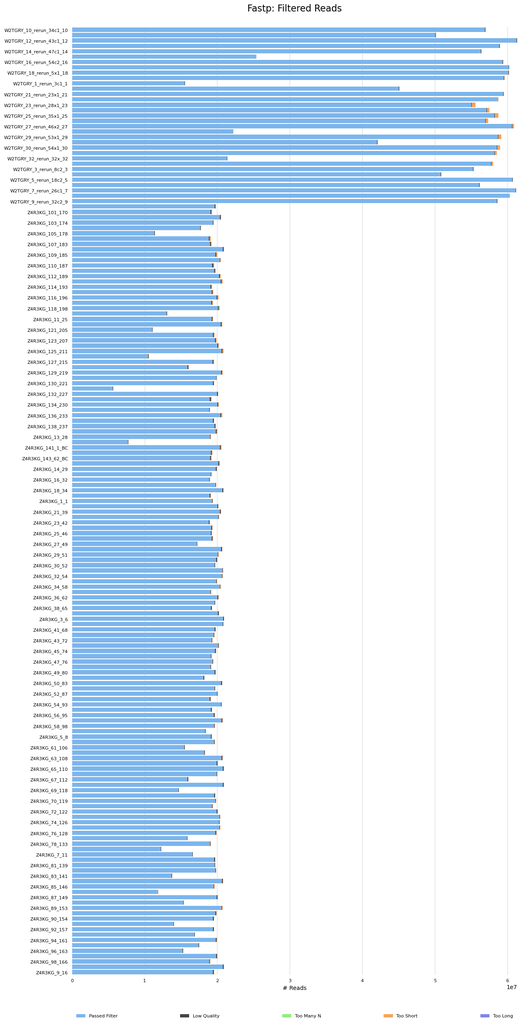

### Sequence Quality

Average sequencing quality over each base of all reads.

Flat image plot. Toolbox functions such as highlighting / hiding samples will not work (see the [docs](http://multiqc.info/docs/#flat--interactive-plots)).

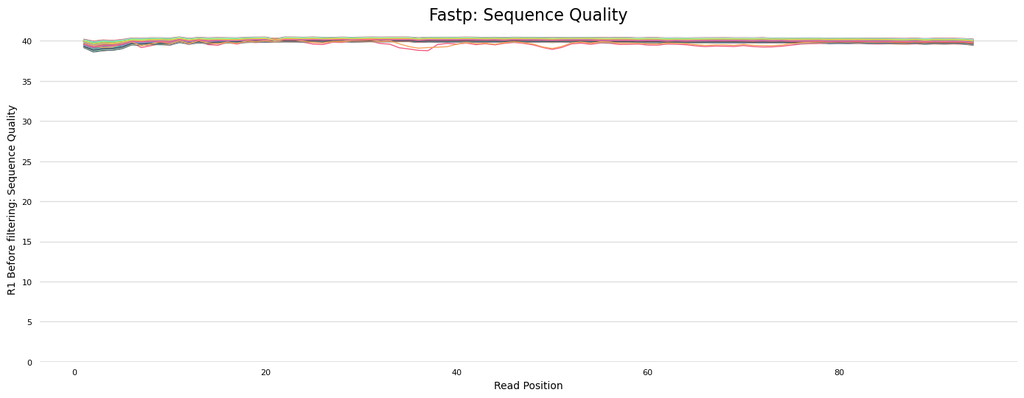

### GC Content

Average GC content over each base of all reads.

Flat image plot. Toolbox functions such as highlighting / hiding samples will not work (see the [docs](http://multiqc.info/docs/#flat--interactive-plots)).

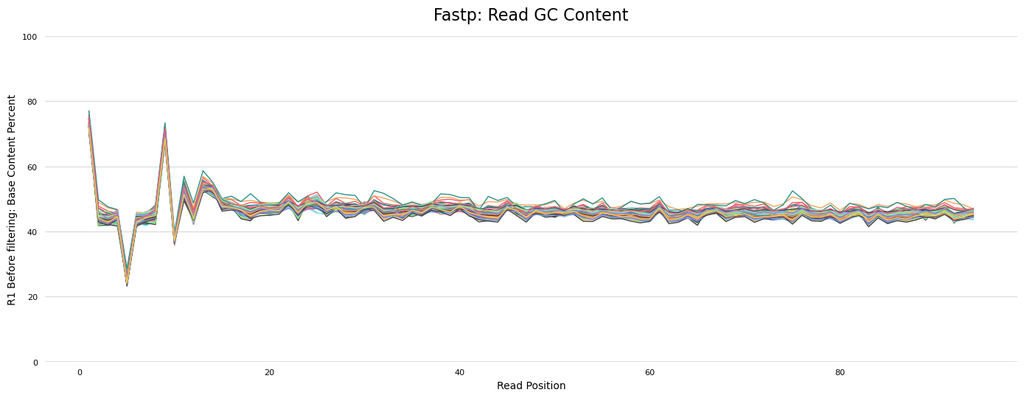

### N content

Average N content over each base of all reads.

Flat image plot. Toolbox functions such as highlighting / hiding samples will not work (see the [docs](http://multiqc.info/docs/#flat--interactive-plots)).

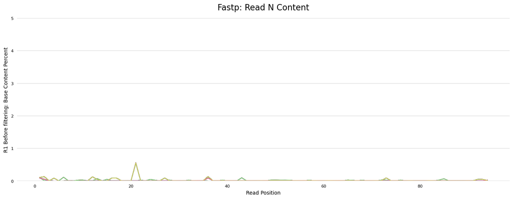

[figure not shown]

**[MultiQC v1.14](http://multiqc.info)** - Written by [Phil Ewels](http://phil.ewels.co.uk), available on [GitHub](https://github.com/ewels/MultiQC).